# Multivariate Regression Exercise

# 1 Data Understanding

You will work on airfoil self noise prediction. Data comes from NASA airfoil testing. Airfoil blade sections were tested with regards to sound emission.

These are the independent variables:

- Frequency, in Hertzs.
- Angle of attack, in degrees.
- Chord length, in meters.
- Free-stream velocity, in meters per second.
- Suction side displacement thickness, in meters.

The target variable is

- Scaled sound pressure level, in decibels.

```r
suppressPackageStartupMessages(library(dplyr))
suppressPackageStartupMessages(library(ggplot2))
suppressPackageStartupMessages(library(corrplot))
suppressPackageStartupMessages(library(caret))
```

# 2 Data Preparation

```r
# if file does not exist, download it first
file_path <- "./data/airfoil_noise.txt"
if (!file.exists(file_path)) {
  dir.create("./data")
  url <- "https://archive.ics.uci.edu/ml/machine-learning-databases/00291/airfoil_self_noise.dat"
  download.file(url = url,
                destfile = file_path)
}
```

Import the data and assign it to object *airfoil_noise*:

```r
airfoil_noise <- read.table(file = file_path)
```

Assign the right column names. Please use these names:

frequency, aoa, chord_length, free_stream_vel, ss_displacement_thickness, spl)

```r
colnames(airfoil_noise) <- c("frequency", "aoa", "chord_length","free_stream_vel", "ss_displacement_thickness", "spl")
```

## 2.1 Exploratory data analysis

Create a correlation plot for the data to understand which variables are most valuable to predict sound pressure level.

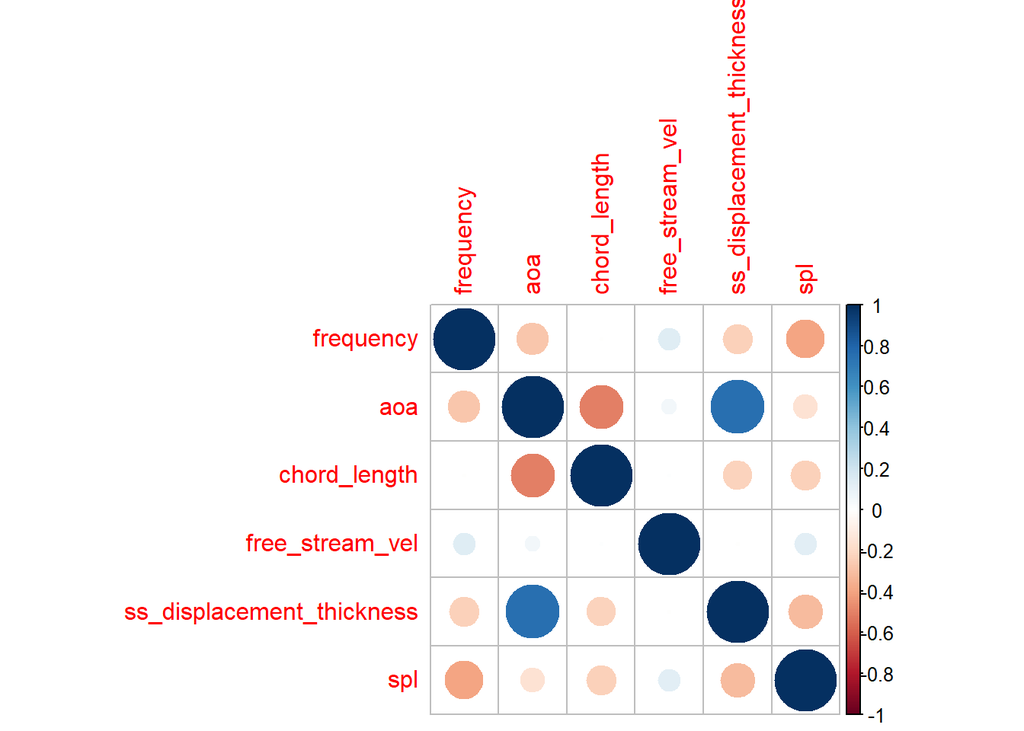

```r
cor_airfoil <- cor(airfoil_noise)
corrplot(cor_airfoil)
```

Which two variables correlate most to target variable?

```r
# this shows the two most correlating vars
cor_airfoil[, 6] %>% sort %>% head(2)
```

```
##                 frequency ss_displacement_thickness
##                -0.3907114                -0.3126695
```

# 3 Model1

## 3.1 Model Creation

Create a multivariate linear regression model based on all independent variables.

```r
model <- lm(formula = spl ~ .,
            data = airfoil_noise)
```

## 3.2 Model Performance

Analyse model performance and get R**2 value:

```r
# create predictions
airfoil_noise$spl_pred <- predict(object = model,
                                  newdata = airfoil_noise)

# perform model performance check
model_summary <- summary(model)
model_summary$adj.r.squared
```

```
## [1] 0.5140922
```

```r
postResample(pred = airfoil_noise$spl_pred, obs = airfoil_noise$spl)
```

```
##      RMSE  Rsquared       MAE
## 4.7992444 0.5157097 3.7285174
```

Does the model overfit? no

Create a visualisation of predicted and actual values.

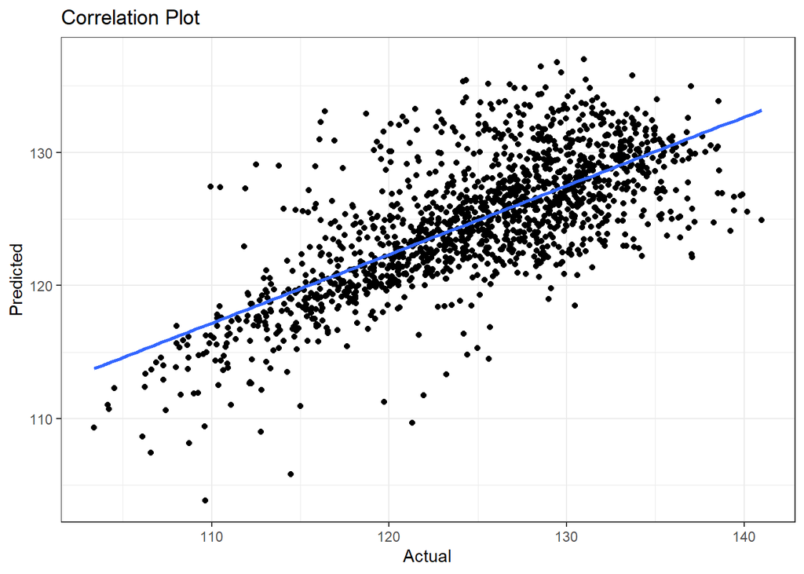

```r
g <- ggplot(airfoil_noise, aes(x = spl, y = spl_pred))
g <- g + geom_point()
g <- g + geom_smooth(method = "lm", se = F)
g <- g + labs(x = "Actual", y = "Predicted", title = "Correlation Plot")
g <- g + theme_bw()
g
```

# 4 Model2

## 4.1 Model Creation

Create a second model with only three independent variables. Which ones do you choose?

```r
model_freq_displ_chord <- lm(formula = spl ~ frequency + ss_displacement_thickness + chord_length,
                            data = airfoil_noise)
```

## 4.2 Model Performance

Analyse model performance and get R**2 value:

```r
# create predictions
airfoil_noise$spl_pred2 <- predict(object = model_freq_displ_chord,
                                   newdata = airfoil_noise)

# perform model performance
postResample(pred = airfoil_noise$spl_pred2,
             obs = airfoil_noise$spl)
```

```
##      RMSE  Rsquared       MAE
## 5.1611332 0.4399199 4.0404212
```

Did the model performance increase?

```r
"No, it decreased"
```

```
## [1] "No, it decreased"
```

# 5 Acknowledgement

This dataset comes from UCI Machine Learning Repository. Here is more information on donor and creators of the data.

Donor: Dr Roberto Lopez robertolopez ‘@’ intelnics.com Intelnics

Creators: Thomas F. Brooks, D. Stuart Pope and Michael A. Marcolini NASA